# EDA - Examination Data

Vincent Pan

2022-10-16

# Goal

Run some Exploratory Data Analysis on the ‘Examination’ data set belonging to National Health and Nutrition Examination Survey.

This will be used to model Blood Pressure Status.

The data dictionary [is linked here](https://wwwn.cdc.gov/Nchs/Nhanes/Search/variablelist.aspx?Component=Examination&CycleBeginYear=2013) for the data set.

# Backgrownd on Blood Pressure

From [WebMd](https://www.webmd.com/hypertension-high-blood-pressure/guide/diastolic-and-systolic-blood-pressure-know-your-numbers): Blood pressure is measured using two numbers: The first number, called systolic blood pressure, measures the pressure in your arteries when your heart beats. The second number, called diastolic blood pressure, measures the pressure in your arteries when your heart rests between beats.

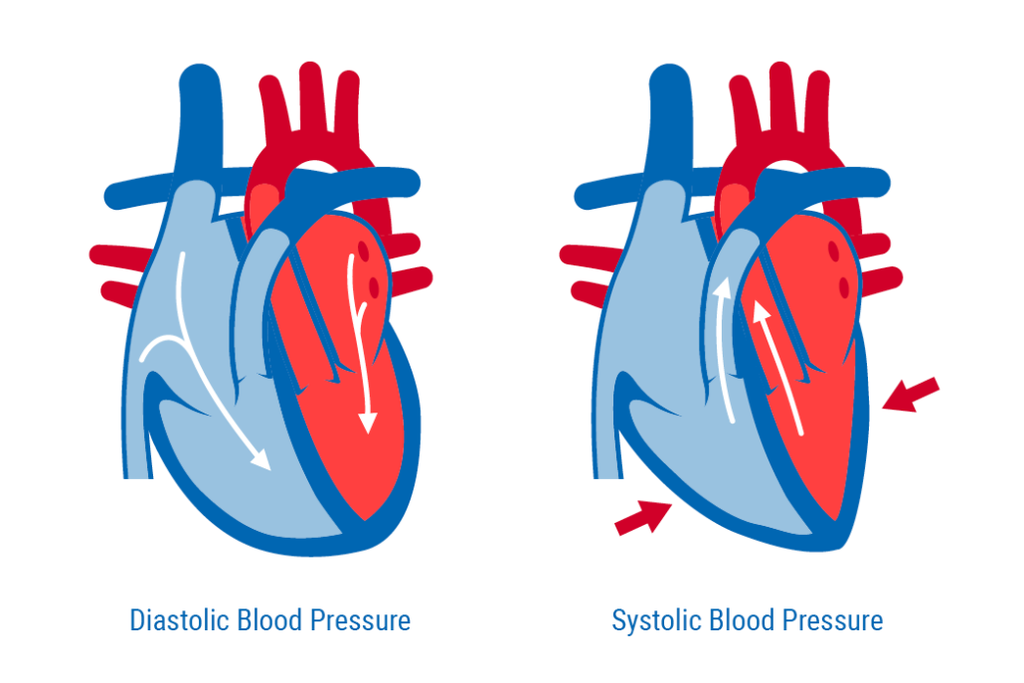

The status or blood pressure category is built on a combination of the two numbers. Below is a chart that illustrates this:

[figure not shown]

# Exploratory Data Analysis

```r
### Load libraries

library(dplyr)
library(tidyverse)
library(ggplot2)
library(corrplot)
library(rvest)
library(xml2)


setwd("C:/Users/Vince/OneDrive/Documents/GitHub/Team-68")
dir.data <- "Data/Original"
dir.code <- "Code/Vincent"
```

```r
### LOAD DATA

### rm(list = ls())
df.examination <- read.csv(paste0(dir.data,"/examination.csv"), stringsAsFactors = FALSE, header = TRUE)
df.examination <- as.data.frame(df.examination)
```

```r
## LOOK AT STRUCTURE OF DATA
str(df.examination, list.len = 5)
```

```
## 'data.frame':    9813 obs. of  224 variables:
##  $ SEQN    : int  73557 73558 73559 73560 73561 73562 73563 73564 73566 73567 ...
##  $ PEASCST1: int  1 1 1 1 1 1 1 1 1 1 ...
##  $ PEASCTM1: int  620 766 665 803 949 1064 90 954 625 932 ...
##  $ PEASCCT1: int  NA NA NA NA NA NA NA NA NA NA ...
##  $ BPXCHR  : int  NA NA NA NA NA NA 152 NA NA NA ...
##   [list output truncated]
```

The Variable PEASCST1 is the ‘Blood Pressure Status’

We also see that there are other Blood Pressure Related Metrics/ Variables. Let’s create two data sets:

1. Blood Pressure (PEASCST1) with the Other Blood Pressure Variables (Variables starting with BP OR PEA): `df.examination.bp`,
2. Blood Pressure (PEASCST1) with non-Blood Pressure Variables. `df.examination.rest`

```r
v.bp.col.list <- c(grep("BP", names(df.examination)), grep("PEA", names(df.examination))) %>% sort
v.bp.col.excl <- v.bp.col.list[v.bp.col.list != grep("PEASCST1", names(df.examination))]

df.examination.bp <- df.examination %>%
                          select(SEQN, v.bp.col.list)
```

```
## Note: Using an external vector in selections is ambiguous.
## ℹ Use `all_of(v.bp.col.list)` instead of `v.bp.col.list` to silence this message.
## ℹ See <https://tidyselect.r-lib.org/reference/faq-external-vector.html>.
```

```r
df.examination.rest <- df.examination %>%
                          select(!v.bp.col.excl)
```

```
## Note: Using an external vector in selections is ambiguous.
## ℹ Use `all_of(v.bp.col.excl)` instead of `v.bp.col.excl` to silence this message.
## ℹ See <https://tidyselect.r-lib.org/reference/faq-external-vector.html>.
```

```r
### Note one column is the identifier
dim(df.examination.rest)
```

```
## [1] 9813  203
```

## Look at how the response variable is distributed

```r
### Understand Blood Pressure
table(df.examination.rest$PEASCST1, useNA = "always")
```

```
##
##    1    2    3 <NA>
## 9493    3  317    0
```

```r
prop.table(table(df.examination.rest$PEASCST1, useNA = "always"))
```

```
##
##            1            2            3         <NA>
## 0.9673901967 0.0003057169 0.0323040864 0.0000000000
```

We see that there are three categories for Blood Pressure that are stored in the data

## Understand State of Missing data

```r
perc.missing.rest <- colSums(is.na(df.examination.rest))/nrow(df.examination.rest)
perc.missing.rest <- as.data.frame(perc.missing.rest)
perc.missing.rest$variable <- rownames(perc.missing.rest)
```

There are a lot of data that is missing

```r
perc.missing.rest.na.perc.dist <- perc.missing.rest %>%
                      mutate(percmissingrestrd = round(perc.missing.rest/0.05)*0.05) %>%
                      group_by(percmissingrestrd) %>%
                      summarize(n_col = n())
```

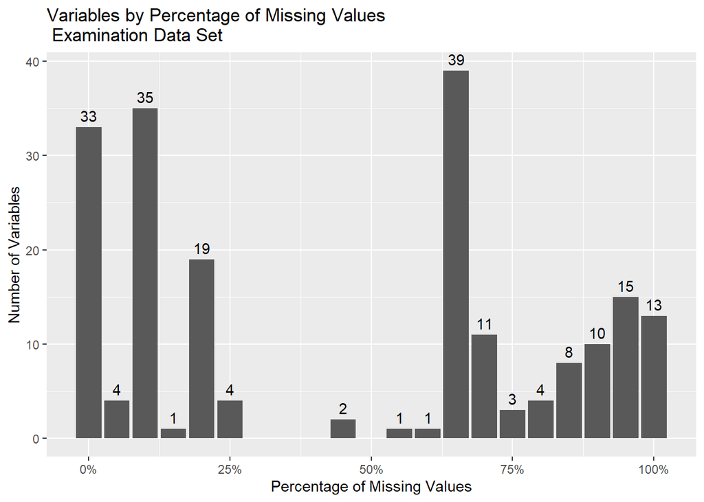

```r
p<-ggplot(data=perc.missing.rest.na.perc.dist, aes(x=percmissingrestrd, y=n_col)) +
  geom_bar(stat="identity")  +
  geom_text(aes(label=n_col), vjust=-0.5) +
  ggtitle("Variables by Percentage of Missing Values \n Examination Data Set") +
  xlab("Percentage of Missing Values") + ylab("Number of Variables") +
  scale_x_continuous(labels = scales::percent)
p
```

Let’s filter to those.

```r
filtered.90pOrMore <- perc.missing.rest %>%
        filter(perc.missing.rest <= 0.1)
```

```r
head(filtered.90pOrMore)
```

```
##          perc.missing.rest variable
## SEQN           0.000000000     SEQN
## PEASCST1       0.000000000 PEASCST1
## BMDSTATS       0.000000000 BMDSTATS
## BMXWT          0.009171507    BMXWT
## BMXHT          0.076021604    BMXHT
## BMXBMI         0.077244472   BMXBMI
```

It’s try to understand them.

First import the data dictionary into R

```r
library(rvest)

url <- "https://wwwn.cdc.gov/Nchs/Nhanes/Search/variablelist.aspx?Component=Examination&CycleBeginYear=2013"
ddictionary <- url %>%
               read_html() %>%
              html_table(fill = TRUE)
ddictionary <- ddictionary[[1]]
ddictionary.df <- as.data.frame(ddictionary)
head(ddictionary)
```

```
## # A tibble: 6 × 8
##   `Variable Name` Variable Des…¹ Data …² Data …³ Begin…⁴ EndYear Compo…⁵ Use C…⁶
##   <chr>           <chr>          <chr>   <chr>     <int>   <int> <chr>   <chr>
## 1 BPAARM          Arm selected:  BPX_H   Blood …    2013    2014 Examin… None
## 2 BPACSZ          Cuff size (cm… BPX_H   Blood …    2013    2014 Examin… None
## 3 BPAEN1          Enhancement u… BPX_H   Blood …    2013    2014 Examin… None
## 4 BPAEN2          Enhancement u… BPX_H   Blood …    2013    2014 Examin… None
## 5 BPAEN3          Enhancement u… BPX_H   Blood …    2013    2014 Examin… None
## 6 BPAEN4          Enhancement u… BPX_H   Blood …    2013    2014 Examin… None
## # … with abbreviated variable names ¹`Variable Description`, ²`Data File Name`,
## #   ³`Data File Description`, ⁴`Begin Year`, ⁵Component, ⁶`Use Constraints`
```

```r
for (variable in filtered.90pOrMore$variable) {
  print(variable)

  ddictionary[which(ddictionary$`Variable Name` == variable), c("Variable Description")] %>%
      as.character() %>%
      print()


  nvalues <- length(table(df.examination.rest[,c(variable)]))
  if (nvalues > 10 ) {print("more than 10 values")
  } else {
  print(table(df.examination.rest[,c(variable)], useNA = "always"))
  }
}
```

```
## [1] "SEQN"
## [1] "c(\"Respondent sequence number.\", \"Respondent sequence number.\", \"Respondent sequence number.\", \"Respondent sequence number.\", \"Respondent sequence number.\", \"Respondent sequence number.\", \"Respondent sequence number.\", \"Respondent sequence number.\", \"Respondent sequence numb…
## [1] "more than 10 values"
## [1] "PEASCST1"
## [1] "Blood Pressure Status"
##
##    1    2    3 <NA>
## 9493    3  317    0
## [1] "BMDSTATS"
## [1] "Body Measures Component status Code"
##
##    1    2    3    4 <NA>
## 9003  317  423   70    0
## [1] "BMXWT"
## [1] "Weight (kg)"
```

[output cut: 272 more lines]

We can observe that there are a lot of tooth related variables.

Instead of predicting on 30 Tooth Code values (OHX##CTC), let’s create a new variable. For each entry, how many D’s, P’s, etc.

I will impute missing variables a median value.

```r
all.values <- data.frame()

for (i in 2:31) {
  i <- 4
  i.str <- str_sub(paste0("0", as.character(i)), start= -2)
  all.values <- c(all.values, unique(df.examination[paste0("OHX",i.str,"CTC")])) %>%
                unlist() %>%
                unique()

}
```

```r
library(reshape)
library(dplyr)
library(tidyr)
```

```r
tooth.health.cols <- df.examination[,grepl("OHX",names(df.examination)) & grepl("CTC",names(df.examination))]
tooth.health.df <- cbind(df.examination$SEQN,tooth.health.cols)
names(tooth.health.df)[1] = "SEQN"
tooth.health.df$row_num <-  seq.int(nrow(tooth.health.df))

tooth.health.df.result <- melt(tooth.health.df, id = c("row_num", "SEQN"))

tooth.health.df.result$value[tooth.health.df.result$value ==""] <- "Delete"
```

```r
tooth.health.df.result.p <- tooth.health.df.result %>%
  group_by(row_num, SEQN) %>%
    count(value) %>%
    pivot_wider(
      names_from = value,
      values_from = n,
      values_fill = 0
    )
tooth.health.df.result.p <- tooth.health.df.result.p %>%
                              select(-Delete)
```

```r
tooth.health.df.result.p <- tooth.health.df.result.p %>%
                                as.data.frame() %>%
                                select(-row_num)
```

```r
head(tooth.health.df.result.p)
```

```
##    SEQN  P  E J  S  Z D K U R  Y M Q T X
## 1 73557 28  0 0  0  0 0 0 0 0  0 0 0 0 0
## 2 73558  0  4 2 17  5 0 0 0 0  0 0 0 0 0
## 3 73559  0  1 0 15 12 0 0 0 0  0 0 0 0 0
## 4 73560  0  0 0 12  0 6 3 7 0  0 0 0 0 0
## 5 73561  0 11 0  2 12 0 0 0 3  0 0 0 0 0
## 6 73562  0  7 1  0  4 0 0 0 6 10 0 0 0 0
```

### Final gathering of columns

We want to get all the relevant columns

```r
relevant.cols.parta <- df.examination[,!(grepl("OHX",names(df.examination)) & grepl("CTC",names(df.examination)))]
```

```r
relevant.cols <- df.examination[, names(df.examination) %in% c("PEASCST1", filtered.90pOrMore$variable)]
relevant.cols <- relevant.cols[,!(grepl("OHX",names(relevant.cols)) & grepl("CTC",names(relevant.cols)))]
relevant.cols <- left_join(relevant.cols,tooth.health.df.result.p, by = c("SEQN" = "SEQN"))
relevant.cols <-relevant.cols %>%
                select(-CSXTSEQ)
      ## This variable relates to Sequence in which whole mouth taste tests were administered.
      ## and not the patient

relevant.cols <- as.data.frame(sapply( relevant.cols, as.numeric ))
```

We will set the NA’s to the most common value for the tooth counts

```r
for (variable in names(relevant.cols)[grepl("OH",names(relevant.cols))]) {
relevant.cols[is.na(relevant.cols[,c(variable)]),c(variable)] <- as.numeric(names(sort(-prop.table(table(relevant.cols[,c(variable)], useNA = "always"))))[1])
}
```

```r
for (variable in names(relevant.cols)[grepl("BMX",names(relevant.cols))]) {

relevant.cols[is.na(relevant.cols[,c(variable)]),c(variable)] <- median(relevant.cols[,c(variable)], na.rm=TRUE)
}
```

# Calculate VIF

```r
model <- lm(PEASCST1  ~., data = relevant.cols)
#load the car library
library(car)
#create vector of VIF values
vif_values <- vif(model)
sort(vif_values)
```

```
##       SEQN   BMDSTATS          T          Y          X    OHX17TC    OHX32TC
##   1.005881   1.069439   1.243945   1.268130   1.837638   2.081041   2.111980
##    OHX01TC    OHX16TC          Z      BMXHT   OHDEXSTS    OHX21TC    OHX22TC
##   2.143785   2.161785   4.333548   6.202132   6.639498   7.958021   8.117587
##    OHX23TC    OHX28TC    OHX20TC    OHX27TC    OHX29TC    OHX26TC    OHX10TC
##   8.315530   8.365948   8.389065   8.390210   8.397360   8.412834   8.458622
##    OHX07TC    OHX11TC    OHX19TC    OHX06TC    OHX03TC    OHX30TC    OHX14TC
##   8.602717   8.746655   8.987449   9.011366   9.035324   9.056280   9.079164
##    OHX08TC    OHX09TC    OHX12TC    OHX05TC    OHX04TC    OHX13TC    OHX02TC
##   9.285667   9.337397   9.384337   9.507338   9.656907   9.682130  10.243508
##    OHX18TC    OHX31TC    OHX15TC    OHX25TC   OHDDESTS    OHX24TC    BMXARML
##  10.302131  10.339851  10.555915  10.682244  10.770091  11.123314  11.498223
##     BMXBMI          S    BMXARMC          K          M          R      BMXWT
##  12.499758  12.853605  13.036596  13.387552  13.893017  16.172460  22.520514
##          Q          J          E          D          U          P
##  50.241576  72.316718 241.699650 258.910535 327.604836 864.024799
```

We see from the first VIF, that P has and Q have a high VIF.

P, Q, R, and X are all missing but replaced tooth so lets remove them ( as the other numbers will act like dummy variable that sum up to the total expect tooth count).

We will also remove the BMI column as we have Weight and Height

```r
relevant.cols.pqr <- relevant.cols %>%
                     select(-c(P, Q, R, X, BMXBMI))
```

And run the VIF again

```r
model <- lm(PEASCST1  ~., data = relevant.cols.pqr)

#create vector of VIF values
vif_values <- vif(model)
sort(vif_values)
```

```
##      SEQN         T  BMDSTATS         Y         J         E         M   OHX17TC
##  1.005506  1.019777  1.051836  1.140790  1.271862  1.582640  1.956467  2.080064
##   OHX32TC   OHX01TC   OHX16TC         K   OHX20TC   OHX19TC   OHX30TC   OHX29TC
##  2.110902  2.141316  2.161401  2.242471  3.137965  3.156358  3.186716  3.259929
##   OHX03TC   OHX14TC         Z   OHX04TC   OHX13TC   OHX31TC   OHX18TC   OHX21TC
##  3.346384  3.425313  3.581196  3.609356  3.621369  3.702975  3.780414  3.860198
##   OHX05TC   OHX15TC   OHX28TC   OHX02TC   OHX12TC   OHX10TC   OHX07TC   OHX06TC
##  3.940299  3.941917  3.966293  3.966511  3.982813  4.376834  4.500011  4.685122
##   OHX11TC   OHX22TC   OHX27TC   OHX08TC   OHX09TC   OHX26TC   OHX23TC     BMXHT
##  4.801308  5.053865  5.237686  5.544743  5.600387  5.714872  5.787270  5.839079
##  OHDEXSTS         U   OHX25TC   BMXARML   OHX24TC  OHDDESTS         S   BMXARMC
##  6.627081  7.526421  8.038198  8.553854  8.608403  9.668349  9.990753 10.075460
##     BMXWT         D
## 10.227093 21.064608
```

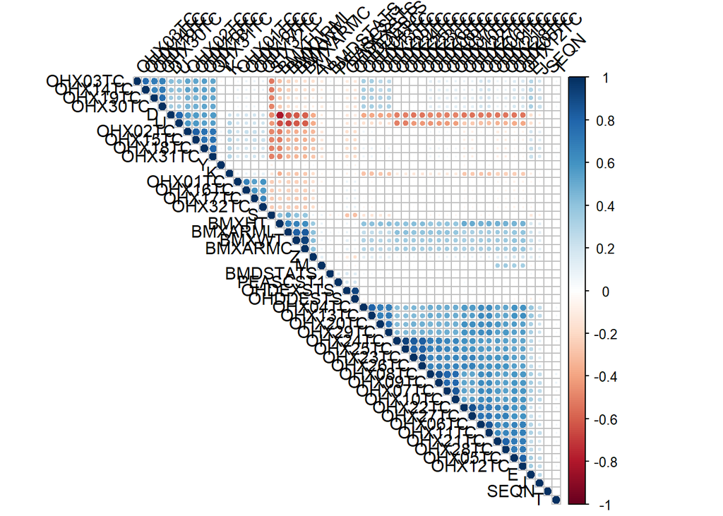

```r
library(corrplot)
res <- cor(relevant.cols.pqr)
corrplot(res, type = "upper", order = "hclust",
         tl.col = "black", tl.srt = 45)
```

We see that there are some highly correlated variables. However this is expected. One healthy tooth probably is very likely to be next to another healthy tooth.

```r
dir.data.clean = "Data/Cleaned"
write.csv(relevant.cols.pqr,paste0(dir.data.clean,"/examination_cleaned.csv"), row.names = TRUE)
```